# basicpython

##### python Introduction

Python is a high-level programming language known for its simple and readable syntax. It has the following features:

- Allows writing clean code with fewer lines.
- Supports multiple programming paradigms including object-oriented, functional and procedural programming.
- Widely used in web development, automation, data analysis, artificial intelligence and many other fields.
- Dynamically typed and has automatic garbage collection
- huge community,large ecosystem,

##### use cases of python

[figure not shown]

```python
print("'hello honey bunny'")
```

```
'hello honey bunny'
```

```python
a=10
print(a)
print(type(a))
```

```
10
<class 'int'>
```

```python
## role of indention in python
# - it is used to define the scope of loops, functions, classes, conditions et
if a>5:
    print("a is greater than 5")
```

```
a is greater than 5
```

#### Input and Output in Python

**Taking Input and printing output:**

```python
# take user name as input and print it
name=input("what is your name?") # input function is used to take input from user. it always returns string
print(name) # print function is used to print the output on console
print(type(name))
```

```
blabla bla
<class 'str'>
```

```python
# formatting in python
# - it is used to format the output in a specific way

name=input("what is your name?")
age=input("what is your age?")
print(f"name is {name}, age is {age}")
```

```
name is bla, age is 66
```

```python
X=int(input("enter a number"))
y=int(input("enter another number"))
print(f"sum of {X} and {y} is {X+y}")
```

```
sum of 77 and 6 is 83
```

##### Python Variables

Variables are used to store data that can be referenced and manipulated during program execution. A variable is essentially a name that is assigned to a value.

- Unlike Java and many other languages, Python variables do not require explicit declaration of type.
- Type of the variable is inferred based on the value assigned.

```python
a=5
print(a)
```

```
5
```

##### Rules for Naming Variables

To use variables correctly, the following naming rules should be followed:

- Names can contain letters, digits and underscores (_).
- The first character cannot be a digit.
- Names are case-sensitive, so myVar and myvar are treated differently.
- Keywords such as if, else and for cannot be used as variable names.

```python
# valid variables
name="honey bunny"
_age=25
address="kathmandu"
```

```python
# invalid variables
# 5name="honey bunny"
# class=10
# user-name="honey bunny"
```

##### Python Keywords

Keywords in Python are special reserved words that are part of the language itself. They define the rules and structure of Python programs which means you cannot use them as names for your variables, functions, classes or any other identifiers

```python
import keyword

# Print the list of all keywords
print(keyword.kwlist)
```

```
['False', 'None', 'True', 'and', 'as', 'assert', 'async', 'await', 'break', 'class', 'continue', 'def', 'del', 'elif', 'else', 'except', 'finally', 'for', 'from', 'global', 'if', 'import', 'in', 'is', 'lambda', 'nonlocal', 'not', 'or', 'pass', 'raise', 'return', 'try', 'while', 'with', 'yield']
```

```python
# deleting a varaibles
a=10
print(a)
del a
print(a)#  # it will give error because a is deleted
```

```
10
```

```
---------------------------------------------------------------------------
NameError                                 Traceback (most recent call last)
Cell In[31], line 5
      3 print(a)
      4 del a
----> 5 print(a)#  # it will give error because a is deleted

NameError: name 'a' is not defined
```

```python
# assigning value to multiple variables
x=y=z=10
print(x)
print(y)
print(z)
```

```
10
10
10
```

```python
# assigning different values to multiple variables
x, y, z = 1, 2.5, "Python"
print(x, y, z)
```

```
1 2.5 Python
```

```python
## swaping values of two variables
a=5
b=10
print(f"before swaping a={a}, b={b}")
a, b = b, a
print(f"after swaping a={a}, b={b}")
```

```
before swaping a=5, b=10
after swaping a=10, b=5
```

##### Python Operators

In Python programming, Operators in general are used to perform operations on values and variables.

- Operators: Special symbols like -, + , * , /, etc.
- Operands: Value on which the operator is applied.

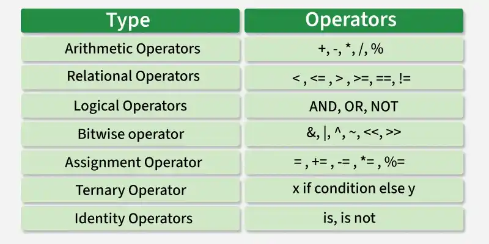